# Scalable plotting with ggplot2 - Part II

## Introduction

This blog post is the follow-up on [part I](https://lorenzwalthert.github.io/proggplotI/) on programming with ggplot2. If you have not read the first post in the series, I strongly recommend doing that before continuing with the second part. After having developed a scalable approach to column-wise and data type-dependent visualization, we will continue to customize our plots. Specifically, the focus of this post is how we can use a log-transformed x-axis with nice breakpoints for continuous data. If you don’t like the idea of having a non-linear scale, don’t stop reading here. The principles developed below can be generalized well to customize the plots regarding other aspects in which the customization depends on the data itself.

## The problem

Recall from part one that we ended up with the following code to produce graphs for two different data types in our data frame with four columns.

```r
##  ............................................................................
##  get set up
library(tidyverse)
source("multiplot.R") # http://www.cookbook-r.com/Graphs/Multiple_graphs_on_one_page_(ggplot2)/
dta <- select(diamonds, price, cut, carat, color)


##  ............................................................................
##  define helper functions
current_class <- function() {
  # returns the first class of the current iteration*
  class(dta[[get("g", parent.frame(n = 2))]])[1]
}
# * first element since object can have multiple classes

geom_hist_or_bar <- function() {
  color <- "gray"
  if (current_class() %in% c("integer", "numeric")) {
  geom_density(color = color, fill = color)
  } else if(current_class() %in% c("factor", "ordered")){
  geom_bar(color = color, fill = color)
  }
}

##  ............................................................................
##  create all plots
all_plots <- lapply(names(dta), function(g) {
  ggplot(dta, aes_(as.name(g))) +
    geom_hist_or_bar()
  }
)
```

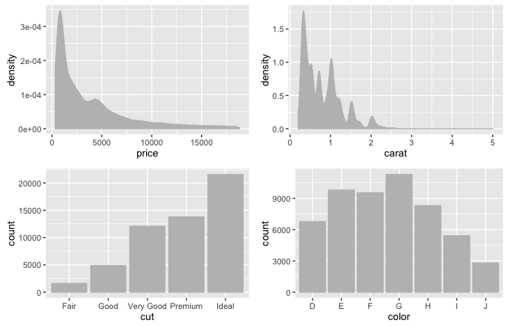

```r
##  ............................................................................
##  compose plots
# use plotlist not ... as input
do.call("multiplot", list(plotlist = all_plots, cols = 2))
```

Our goal is to alter the x-axis from a linear to a log-transformed scale to make better use of the space in the plot.

## A fist solution

At first glance, this seems easy. Similarly to the first post of this series, we can create a new function `scale_x_adapt` which returns a continuous scale with a log transformation for continuous data and a discrete scale otherwise. Then we can integrate it in our current framework.

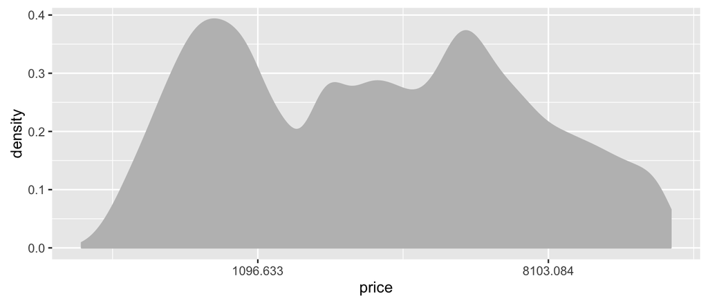

```r
##  ............................................................................
##  create a scale function
scale_x_adapt <- function(...) {
  if (current_class() %in% c("integer", "numeric")) {
    scale_x_continuous(...)
  } else {
    scale_x_discrete()
  }
}


##  ............................................................................
##  integrate this function in our lapply framework
all_plots <- lapply(names(dta), function(g) {
  ggplot(dta, aes_(as.name(g))) +
    geom_hist_or_bar() +
    scale_x_adapt(trans = "log")
})
all_plots[[1]]
```

This seems fine, except for the fact that the break ticks are not really chosen wisely. There are various ways to go about that:

- Resort to functionality from existing packages like `trans_breaks` (from the scales package), `annotation_logticks` (ggplot2) and others.
- create your own function that returns pretty breaks.

We go for the second option because it is a slightly more general approach and I was not able to find a solution that pleased me four our specific case.

## A second solution

We need to change the way the breaks are created within `scale_x_adapt`. To produce appropriate breaks, we need to know the maximum and the minimum of the data we are dealing (that is, the column that `lapply` currently passes over) and then create a sequence between the minimum and the maximum with some function. Recall that we use a function `current_class` that does something similar to what we want. It gets the class of the current data. Hence, we can expand this function to get any property from our current data (and give the function a more general name).

```r
current_property <- function(f) {
  # returns a property of the current iteration object
  f(dta[[get("g", parent.frame(n = 2))]])
}

# where the follwing is equivalent
current_class()
current_property(f = class)[1]
```

Note the new argument f, which allows us get a wider range of properties of the current data, not just the class, as `current_class` did.

This is key for every customization that depends on the input data, because this function can now get us virtually any information out of the data we could possibly want. In our case, we are interested in the minimal and maximal value of the current data batch. As a detail, also note that `current_class` called `class` and returned the first value, since objects can had multiple classes and we were only interested in the first one (otherwise we could not do the logical comparison with `%in%`). We now return all elements that `f` returns, since we can always do the subset outside the function `current_property`, which means the function gains in flexibility.

Next, we need is to create a function that, given a range, computes some nice break values we can pass to the `breaks` argument of `scale_x_continuous`. This task is independent of the rest of the framework we are developing here. One function that does something that is close to what we want is the following.

```r
### .. . . . . . . . . . . . . . . . . . . . . . . . . . . . . . . . . . . . . .
### break calculation
calc_log_breaks <- function(min, max,
                        length = 5,
                        correction = 2) {

  # calculate sequence of log values
  sequence <- seq(log(min), log(max), length.out = length)

  # exponentiate sequcence and round depending on range
  round(exp(sequence), digits = -log10(max - min) + correction)
}
```

Finally, we can put it all together:

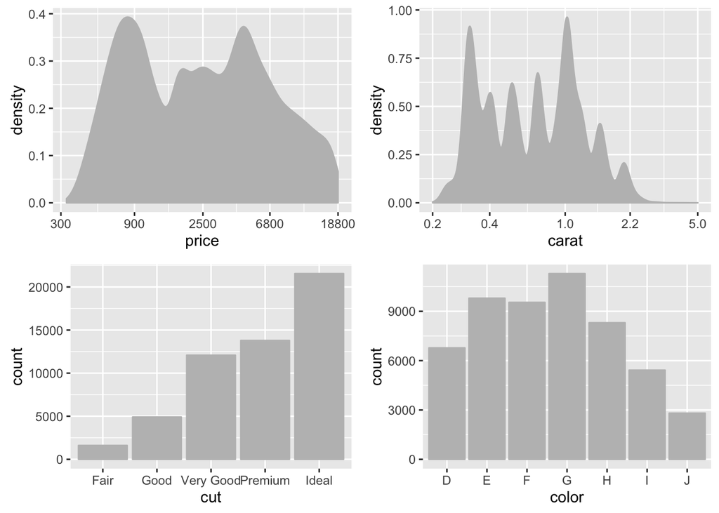

```r
##  ............................................................................
##  define helper-funtions
current_property <- function(f, n = 2) {
  # returns a property of the current iteration object
  f(dta[[get("g", parent.frame(n = n))]])
}

# returns a histogram or a bar geom, depending on class
geom_hist_or_bar <- function() {
  color <- "gray"
  if (current_property(class)[1] %in% c("integer", "numeric")) {
  geom_density(color = color, fill = color)
  } else {
  geom_bar(color = color, fill = color)
  }
}

### .. . . . . . . . . . . . . . . . . . . . . . . . . . . . . . . . . . . . . .
### break calculation

calc_log_breaks <- function(min, max,
                        length = 5,
                        correction = 2) {

  # calculate sequence of log values
  sequence <- seq(log(min), log(max), length.out = length)

  # exponentiate sequcence and round depending on range
  round(exp(sequence), -log10(max - min) + correction)
}

### .. . . . . . . . . . . . . . . . . . . . . . . . . . . . . . . . . . . . . .
### returns appropriate scale

scale_x_adapt <- function(...) {
  if (current_property(class)[1] %in% c("integer", "numeric")) {
    scale_x_continuous(breaks = calc_log_breaks(min = current_property(min),
                                                max = current_property(max)), ...)
  } else {
    scale_x_discrete()
  }

}


##  ............................................................................
##  generate plots
all_plots <- lapply(names(dta), function(g) {
  ggplot(dta, aes_(as.name(g))) +
    geom_hist_or_bar() +
    scale_x_adapt(trans = "log")
})


##  ............................................................................
##  compose the plots
# use plotlist not ... as input
do.call("multiplot", list(plotlist = all_plots, cols = 2))
```

## Conclusion

In this blog post, we introduced a new function, `scale_x_adapt` that returns a predefined scale for a given data type. It can be integrated in our framework similarly to `geom_hist_or_bar`. We created a more general version of `current_class`, `current_property` which takes a function as an argument and allows us evaluate this function to the currently processed data column. In our example, this is helpful because using `current_property(min)` and `current_property(max)`, we found out the range of the column we are processing and hence construct nice breakpoints with `calc_log_breaks` that were used in `scale_x_adapt`.